# EP02-respuesta-equipo-4

Daniel Monares - Franco Saravia

2025-08-29

# Ejercicio Práctico 2

El presente informe tiene como intención responder las preguntas del Ejercicio Práctico 2 para el equipo 4. El contexto con el que se está trabajando es que El Comité Olímpico de una gran potencia del atletismo está estudiando el programa de entrenamiento de varones para la competencia de 100 metros planos, por lo que ha recopilado datos de una muestra aleatoria de atletas.

Para comenzar, leemos el conjunto de datos entregado que contiene la muestra de los atletas.

```r
# Leemos el conjunto de datos
data <- read.csv2("EP02 Datos.csv")

# Mostramos algunos datos de la tabla
head(data)
```

```
##   Id         Zona Previo Posterior
## 1  1   Centro-Sur 19.926    15.170
## 2  2   Centro-Sur 21.359    16.306
## 3  3 Centro-Norte 17.219    14.020
## 4  4   Centro-Sur 18.245    13.069
## 5  5          Sur 12.890    11.533
## 6  6 Centro-Norte 15.805    13.382
```

Luego, vemos cuáles son los tipos de las variables del conjunto

```r
library(dplyr)

glimpse(data)
```

```
## Rows: 81
## Columns: 4
## $ Id        <int> 1, 2, 3, 4, 5, 6, 7, 8, 9, 10, 11, 12, 13, 14, 15, 16, 17, 1…
## $ Zona      <chr> "Centro-Sur", "Centro-Sur", "Centro-Norte", "Centro-Sur", "S…
## $ Previo    <dbl> 19.926, 21.359, 17.219, 18.245, 12.890, 15.805, 20.152, 13.1…
## $ Posterior <dbl> 15.170, 16.306, 14.020, 13.069, 11.533, 13.382, 15.848, 11.9…
```

Como se puede observar, todos los tipos de datos para cada variable del dataset están bien a excepción de Zona, que es una variable categórica nominal, vamos a cambiarlo para mantener las buenas practicas.

```r
# Modificar el tipo de dato de Zona
data[["Zona"]] <- factor(data[["Zona"]])

glimpse(data)
```

```
## Rows: 81
## Columns: 4
## $ Id        <int> 1, 2, 3, 4, 5, 6, 7, 8, 9, 10, 11, 12, 13, 14, 15, 16, 17, 1…
## $ Zona      <fct> Centro-Sur, Centro-Sur, Centro-Norte, Centro-Sur, Sur, Centr…
## $ Previo    <dbl> 19.926, 21.359, 17.219, 18.245, 12.890, 15.805, 20.152, 13.1…
## $ Posterior <dbl> 15.170, 16.306, 14.020, 13.069, 11.533, 13.382, 15.848, 11.9…
```

Una vez que se cambió el tipo de dato de Zona, se vuelven a mostrar los tipos de dato para confirmar que el cambio se realizó. Teniendo todos los tipos de datos correctos, procedemos a responder las preguntas planteadas.

### 1. El Comité Olímpico cree que el mejor tiempo medio de los atletas de la zona Sur antes de ingresar al programa de entrenamiento era inferior a 14,3 segundos. ¿Soportan los datos esta afirmación?

Para abordar la pregunta, antes debemos darnos cuenta de unas cosas. La variable de interés de esta pregunta es el mejor tiempo registrado previo al entrenamiento, el cual es del tipo numérica continua. El parámetro que debemos estudiar es la media de los tiempos previos de atletas de la zona sur.

Una vez que sabemos esto, la hipótesis nula a verificar es la siguiente:

$H_{0}$: El mejor tiempo medio de los atletas de la zona sur antes de ingresar al programa es de 14,3 segundos exactamente, Matemáticamente está representado como $\mu=14,3$.

Por ende, su hipótesis alternativa es:

$H_{A}$: El mejor tiempo medio es menor a 14,3 segundos, Matemáticamente está representado como $\mu<14,3$.

Una vez definidas las hipótesis, para poder responder esta pregunta primero debemos filtrar los datos que nos piden, osea, seleccionar solo los atletas de la zona sur y sus tiempos antes de ingresar al programa de entrenamiento.

```r
# Seleccionamos los datos que nos interesan
tiemposAntesSur <- data %>% filter(Zona == "Sur") %>% select(Previo)

# Tamaño de la muestra
tamano <- length(tiemposAntesSur[["Previo"]])

cat("El tamaño de la muestra es:", tamano)
```

```
## El tamaño de la muestra es: 28
```

Las pruebas que pueden responder la pregunta son la prueba Z o la prueba t de Student. Como el tamaño de la muestra es menor a 30 la prueba Z queda descartada, ya que la prueba t de Student es mejor con muestras menores a 30.

Ahora verificamos que se cumplan las condiciones para usar la prueba t de Student. Como el enunciado nos dice que se seleccionó una muestra aleatoria de atletas, y por consecuencia la elección y rendimiento de un atleta no condiciona la elección o rendimiento de otro, es posible confirmar que la muestra cumple con la condición de observaciones independientes. Ahora para saber si los datos siguen una distribución normal o cercana a esta, usamos la prueba de Shapiro-Wilk y el gráfico Q-Q (Quantile-Quantile plot), se usan ambos metodos para que la conclusión sea más fundamentada.

```r
# Prueba de Shapiro
cat("El valor p de la prueba de Shapiro para normalidad es: p =", shapiro.test(tiemposAntesSur[["Previo"]])$p)
```

```
## El valor p de la prueba de Shapiro para normalidad es: p = 0.6630897
```

Continuando con la constuccion del gráfico Q-Q tenemos:

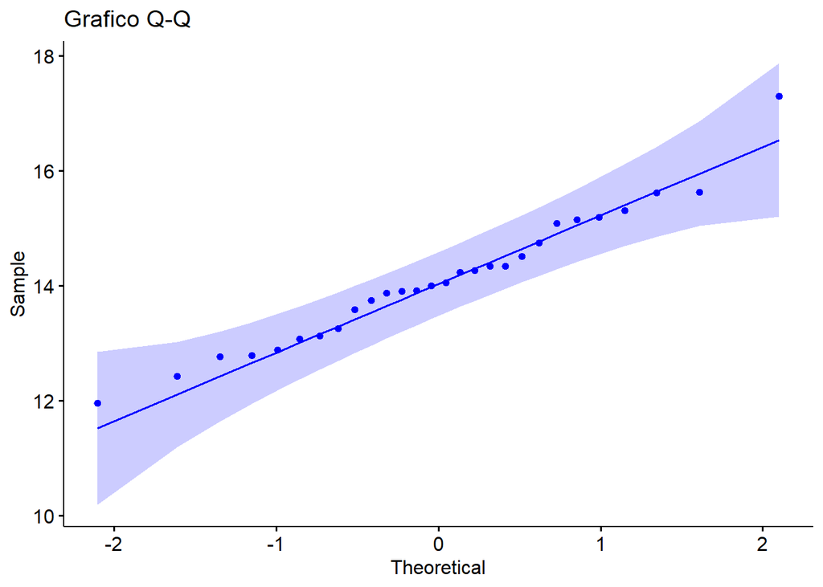

```r
library(ggpubr)

# Gráfico Q-Q
g <- ggqqplot(tiemposAntesSur, x = "Previo", title = "Grafico Q-Q", color = "blue")
plot(g)
```

Con el resultado del valor p es igual a 0.663 y observando el gráfico Q-Q, podemos concluir que la muestra sigue una distribución muy cercana a una distribución normal.

Con las dos condiciones verificadas, aplicamos la prueba t para la media de una muestra unilateral. Como lo que estamos investigando no es algo crítico, y cometer un error de tipo I no es algo grave (teniendo en cuenta el contexto entregado), vamos a considerar un nivel de confianza del 95% (significancia ,05).

```r
valorNulo = 14.3
confianza = 0.95

# Prueba t para una muestra y una cola (derecha)
t.test(tiemposAntesSur, alternative = "less", mu = valorNulo, conf.level = confianza)
```

```
##
##  One Sample t-test
##
## data:  tiemposAntesSur
## t = -0.85832, df = 27, p-value = 0.1991
## alternative hypothesis: true mean is less than 14.3
## 95 percent confidence interval:
##      -Inf 14.48406
## sample estimates:
## mean of x
##  14.11304
```

Tal como el resultado de la prueba muestra, el valor p es igual a 0.199, osea, es más alto que la significancia elegida $\alpha$ = 0,05. Por lo tanto, la evidencia muestra que no hay pruebas suficiente para rechazar a la hipótesis nula.

### 2. ¿Sugieren los datos que la mejor marca de los atletas de la zona Centro-Norte se reduce en promedio más de 3,4 segundos tras el entrenamiento?

La pregunta apunta a conocer si es cierto que el mejor tiempo medio de los atletas de la zona Centro-Norte se ha reducido en promedio más de 3,4 segundos tras el entrenamiento. En otras palabras, si la media de las diferencias entre los tiempos previo y posterior de cada atleta ha disminuido. Las variables que nos interesan son los tiempos anteriores y posteriores al entrenamiento. Considerando $dif=t_{previo}-t_{posterior}$, las hipótesis son las siguientes:

$H_{0}$: La media de las diferencias entre los tiempos de cada atleta después del programa de entrenamiento es igual a 3,4 segundos, es decir, $\mu_{dif}=3,4$

Antes de decidir que prueba de hipótesis usar para resolver la pregunta, debemos darnos cuenta de una característica importante: estamos trabajando con dos muestras, tiempo previo y posterior. Como cada observación de una muestra está directamente relacionada con otra del otro conjunto, esto es tiempos previo y posterior de la misma persona, se trata de dos muestras pareadas.

Ya que la pregunta está orientada al parámetro de la media, y es un caso de dos muestras pareadas, la prueba de hipótesis más apropiada es la prueba t de Student para dos muestras pareadas. Luego, procedemos a revisar sus condiciones.

Al igual que el problema anterior, la muestra elegida es aleatoria y el rendimiento de un atleta no afecta el de los demás, por lo tanto las observaciones son independientes en cada conjunto de datos. Para probar normalidad del conjunto, aplicamos el test de Shapiro-Wilk a la diferencia de las muestras.

```r
#Filtramos los datos
tiemposCentroNorte <- data %>% filter(Zona=="Centro-Norte") %>% select(Previo, Posterior)

# Diferencia de muestras
diferencia <- tiemposCentroNorte[["Previo"]] - tiemposCentroNorte[["Posterior"]]

# Prueba de Shapiro
cat("El valor p de la prueba de Shapiro para normalidad de la diferencia de muestras es: p =", shapiro.test(diferencia)$p)
```

```
## El valor p de la prueba de Shapiro para normalidad de la diferencia de muestras es: p = 0.337459
```

El valor del estadístico p de la prueba es p = 0,337. Entonces se confirma que la distribución de la diferencia entre tiempos de los atletas sigue, o es cercana, a la distribución normal, no se realizó el grafico Q-Q ya que al ser una diferencia entre los tiempos es más complicado graficarlo.

Una vez verificadas estas condiciones, podemos aplicar la prueba t de Student para dos muestras pareadas. La significancia que usaremos va a ser nuevamente 95% por los mismos motivos que en la pregunta 1.

```r
valorNulo = 3.4
confianza = 0.95

# Prueba t para dos muestras dependientes y una cola (derecha)
t.test(x = tiemposCentroNorte[["Previo"]], y = tiemposCentroNorte[["Posterior"]],
       paired = TRUE, alternative = "less", mu = valorNulo, conf.level = confianza)
```

```
##
##  Paired t-test
##
## data:  tiemposCentroNorte[["Previo"]] and tiemposCentroNorte[["Posterior"]]
## t = -3.4035, df = 25, p-value = 0.001124
## alternative hypothesis: true mean difference is less than 3.4
## 95 percent confidence interval:
##      -Inf 3.243897
## sample estimates:
## mean difference
##        3.086615
```

El valor p de la prueba es p = 0,001 y el intervalo de confianza es $(-\infty,3.244]$. El valor p es menor a la significancia (p < $\alpha$), lo que significa la evidencia nos sugiere rechazar la hipótesis nula en favor de la hipótesis alternativa.